# DeconPeaker, a deconvolution model to estimate cell type proportions of mixtures.

Wrote by Huamei Li  
State Key Laboratory of Bioelectronics, School of Biological Science & Medical Engineering, Southeast University, Nanjing 210096, China;  
Source: DeconPeaker_demo.ipynb

## Demonstrate how DeconPeaker works

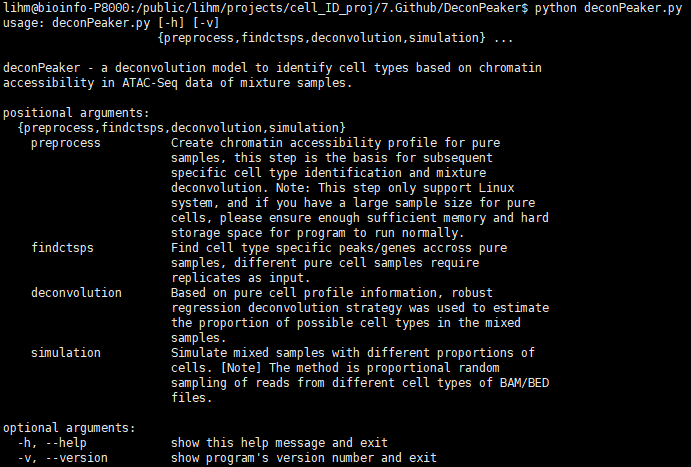

## Preprocessing chromatin accessibility datasets

DeconPeaker provides a commond line to process chromatin accessibility datasets except gene expression datasets, and this step only supports Linux system. The input file must be YAML format, and including five keys. *1) sample_ID: unique sample ID for each sample.*2) bam: BAM of aligned file path *3) batch: batch ID of each sample, if cell type has replicates, batch ID must be the same.*4) cellname: cell name of the pure sample. *5) peak: peak file path of the sample. The test YAML format file can see in test/GSE74912_ATAC_pure_cells.yaml

```python
# python deconPeaker.py preprocess --pure=test/GSE74912_ATAC_pure_cells.yaml --thread=10 --prefix=Test --outdir=results
```

This commond line will create a directory, named "preprocess", including count matrix file and phenotype class file. Both files are the basis for the subsequent analysis.

```python
import matplotlib
import matplotlib.pyplot as plt
import pandas as pd
import seaborn as sns; sns.set()
import matplotlib.image as mpimg
%matplotlib inline
```